# ANCOVA test for matematica (engajamento no matematica)

Geiser C. Challco geiser@alumni.usp.br

- Descriptive Statistics of Initial Data
- Checking of Assumptions
  - Assumption: Normality distribution of data
  - Assumption: Homogeneity of data distribution
- Computation of ANCOVA test and Pairwise Comparison
  - ANCOVA tests for one factor
  - ANCOVA tests for two factors
  - ANCOVA tests for grupo=“Experimental”
  - Pairwise comparisons for one factor
    - factor: **grupo**
    - factor: **genero**
    - factor: **idade**
    - factor: **zona.participante**
    - factor: **escola**
    - factor: **zona.escola**
  - Pairwise comparisons for two factors
    - factores: **grupo:genero**
    - factores: **grupo:idade**
    - factores: **grupo:zona.participante**
    - factores: **grupo:escola**
    - factores: **grupo:zona.escola**
  - Pairwise comparisons for grupo=“Experimental”
    - factores: **grupo=“Experimental”:monitor**
    - factores: **grupo=“Experimental”:monitor.genero**
    - factores: **grupo=“Experimental”:monitor.area**
    - factores: **grupo=“Experimental”:monitor.formacao**
    - factores: **grupo=“Experimental”:monitor.experiencia**

**NOTE**

- Teste ANCOVA para determinar se houve diferenças significativas em referência ao engajamento no matematica (medido como estado de fluxo).
- ANCOVA test to determine whether there were significant differences in reference to engagement in matematica (measured as flow state).

# Descriptive Statistics of Initial Data

| grupo | genero | idade | zona.participante | escola | zona.escola | variable | n | mean | median | min | max | sd | se | ci | iqr |
| --- | --- | --- | --- | --- | --- | --- | --- | --- | --- | --- | --- | --- | --- | --- | --- |
| Controle | F |  |  |  |  | fss.matematica | 60 | 3.401 | 3.389 | 2.000 | 4.333 | 0.522 | 0.067 | 0.135 | 0.778 |
| Controle | M |  |  |  |  | fss.matematica | 65 | 3.363 | 3.333 | 2.444 | 4.444 | 0.482 | 0.060 | 0.120 | 0.556 |
| Experimental | F |  |  |  |  | fss.matematica | 57 | 3.487 | 3.444 | 2.444 | 4.444 | 0.540 | 0.071 | 0.143 | 0.889 |
| Experimental | M |  |  |  |  | fss.matematica | 75 | 3.448 | 3.444 | 1.778 | 4.714 | 0.599 | 0.069 | 0.138 | 0.833 |
| Controle | F |  |  |  |  | dfs.matematica | 60 | 3.510 | 3.556 | 2.000 | 4.556 | 0.584 | 0.075 | 0.151 | 0.694 |
| Controle | M |  |  |  |  | dfs.matematica | 65 | 3.546 | 3.556 | 2.444 | 4.556 | 0.483 | 0.060 | 0.120 | 0.667 |
| Experimental | F |  |  |  |  | dfs.matematica | 57 | 3.559 | 3.667 | 2.333 | 4.857 | 0.585 | 0.078 | 0.155 | 0.778 |
| Experimental | M |  |  |  |  | dfs.matematica | 75 | 3.419 | 3.444 | 1.667 | 4.556 | 0.538 | 0.062 | 0.124 | 0.667 |
| Controle |  | 10y |  |  |  | fss.matematica | 24 | 3.435 | 3.444 | 2.444 | 4.444 | 0.508 | 0.104 | 0.214 | 0.500 |
| Controle |  | 11y |  |  |  | fss.matematica | 67 | 3.374 | 3.333 | 2.000 | 4.444 | 0.504 | 0.062 | 0.123 | 0.556 |
| Controle |  | 12y |  |  |  | fss.matematica | 18 | 3.474 | 3.333 | 2.778 | 4.333 | 0.509 | 0.120 | 0.253 | 0.667 |
| Controle |  | 13y |  |  |  | fss.matematica | 7 | 3.058 | 2.889 | 2.778 | 3.625 | 0.320 | 0.121 | 0.296 | 0.389 |
| Controle |  | 14y |  |  |  | fss.matematica | 1 | 3.556 | 3.556 | 3.556 | 3.556 |  |  |  | 0.000 |
| Controle |  | 15y |  |  |  | fss.matematica | 1 | 2.444 | 2.444 | 2.444 | 2.444 |  |  |  | 0.000 |
| Controle |  | 16y |  |  |  | fss.matematica | 1 | 3.000 | 3.000 | 3.000 | 3.000 |  |  |  | 0.000 |
| Controle |  |  |  |  |  | fss.matematica | 6 | 3.537 | 3.611 | 3.000 | 4.222 | 0.484 | 0.198 | 0.508 | 0.667 |
| Experimental |  | 10y |  |  |  | fss.matematica | 24 | 3.287 | 3.333 | 1.778 | 4.444 | 0.650 | 0.133 | 0.275 | 0.917 |
| Experimental |  | 11y |  |  |  | fss.matematica | 80 | 3.557 | 3.611 | 1.889 | 4.714 | 0.538 | 0.060 | 0.120 | 0.694 |
| Experimental |  | 12y |  |  |  | fss.matematica | 16 | 3.429 | 3.611 | 2.444 | 4.222 | 0.538 | 0.135 | 0.287 | 0.806 |
| Experimental |  | 13y |  |  |  | fss.matematica | 9 | 3.094 | 3.222 | 1.889 | 3.778 | 0.537 | 0.179 | 0.413 | 0.222 |
| Experimental |  | 14y |  |  |  | fss.matematica | 1 | 4.444 | 4.444 | 4.444 | 4.444 |  |  |  | 0.000 |
| Experimental |  |  |  |  |  | fss.matematica | 2 | 3.389 | 3.389 | 3.333 | 3.444 | 0.079 | 0.056 | 0.706 | 0.056 |
| Controle |  | 10y |  |  |  | dfs.matematica | 24 | 3.427 | 3.410 | 2.222 | 4.556 | 0.519 | 0.106 | 0.219 | 0.646 |
| Controle |  | 11y |  |  |  | dfs.matematica | 67 | 3.588 | 3.667 | 2.000 | 4.556 | 0.529 | 0.065 | 0.129 | 0.667 |
| Controle |  | 12y |  |  |  | dfs.matematica | 18 | 3.560 | 3.646 | 2.750 | 4.333 | 0.484 | 0.114 | 0.241 | 0.722 |
| Controle |  | 13y |  |  |  | dfs.matematica | 7 | 3.683 | 3.778 | 3.000 | 4.556 | 0.519 | 0.196 | 0.480 | 0.556 |
| Controle |  | 14y |  |  |  | dfs.matematica | 1 | 3.444 | 3.444 | 3.444 | 3.444 |  |  |  | 0.000 |
| Controle |  | 15y |  |  |  | dfs.matematica | 1 | 2.444 | 2.444 | 2.444 | 2.444 |  |  |  | 0.000 |
| Controle |  | 16y |  |  |  | dfs.matematica | 1 | 3.444 | 3.444 | 3.444 | 3.444 |  |  |  | 0.000 |
| Controle |  |  |  |  |  | dfs.matematica | 6 | 3.222 | 3.000 | 2.667 | 4.556 | 0.692 | 0.283 | 0.726 | 0.417 |
| Experimental |  | 10y |  |  |  | dfs.matematica | 24 | 3.463 | 3.444 | 2.333 | 4.556 | 0.546 | 0.111 | 0.231 | 0.583 |
| Experimental |  | 11y |  |  |  | dfs.matematica | 80 | 3.514 | 3.472 | 2.333 | 4.857 | 0.558 | 0.062 | 0.124 | 0.795 |
| Experimental |  | 12y |  |  |  | dfs.matematica | 16 | 3.398 | 3.389 | 1.667 | 4.333 | 0.646 | 0.161 | 0.344 | 0.500 |
| Experimental |  | 13y |  |  |  | dfs.matematica | 9 | 3.321 | 3.556 | 2.556 | 4.000 | 0.568 | 0.189 | 0.436 | 1.000 |
| Experimental |  | 14y |  |  |  | dfs.matematica | 1 | 3.000 | 3.000 | 3.000 | 3.000 |  |  |  | 0.000 |
| Experimental |  |  |  |  |  | dfs.matematica | 2 | 3.889 | 3.889 | 3.889 | 3.889 | 0.000 | 0.000 | 0.000 | 0.000 |
| Controle |  |  | Urbana |  |  | fss.matematica | 54 | 3.381 | 3.389 | 2.444 | 4.444 | 0.514 | 0.070 | 0.140 | 0.667 |
| Controle |  |  | Rural |  |  | fss.matematica | 43 | 3.376 | 3.333 | 2.000 | 4.444 | 0.464 | 0.071 | 0.143 | 0.535 |
| Controle |  |  |  |  |  | fss.matematica | 28 | 3.390 | 3.556 | 2.444 | 4.333 | 0.544 | 0.103 | 0.211 | 0.917 |
| Experimental |  |  | Urbana |  |  | fss.matematica | 49 | 3.375 | 3.333 | 1.889 | 4.714 | 0.624 | 0.089 | 0.179 | 1.000 |
| Experimental |  |  | Rural |  |  | fss.matematica | 53 | 3.486 | 3.667 | 1.778 | 4.444 | 0.552 | 0.076 | 0.152 | 0.667 |
| Experimental |  |  |  |  |  | fss.matematica | 30 | 3.574 | 3.611 | 2.556 | 4.556 | 0.514 | 0.094 | 0.192 | 0.667 |
| Controle |  |  | Urbana |  |  | dfs.matematica | 54 | 3.437 | 3.444 | 2.222 | 4.333 | 0.500 | 0.068 | 0.136 | 0.549 |
| Controle |  |  | Rural |  |  | dfs.matematica | 43 | 3.555 | 3.556 | 2.000 | 4.556 | 0.594 | 0.091 | 0.183 | 0.889 |
| Controle |  |  |  |  |  | dfs.matematica | 28 | 3.666 | 3.667 | 2.778 | 4.556 | 0.472 | 0.089 | 0.183 | 0.583 |
| Experimental |  |  | Urbana |  |  | dfs.matematica | 49 | 3.382 | 3.333 | 1.667 | 4.857 | 0.598 | 0.085 | 0.172 | 0.667 |
| Experimental |  |  | Rural |  |  | dfs.matematica | 53 | 3.517 | 3.444 | 2.556 | 4.556 | 0.552 | 0.076 | 0.152 | 0.778 |
| Experimental |  |  |  |  |  | dfs.matematica | 30 | 3.574 | 3.667 | 2.444 | 4.333 | 0.507 | 0.093 | 0.189 | 0.500 |
| Controle |  |  |  | E1 |  | fss.matematica | 12 | 3.120 | 3.167 | 2.444 | 4.222 | 0.516 | 0.149 | 0.328 | 0.694 |
| Controle |  |  |  | E2 |  | fss.matematica | 23 | 3.314 | 3.222 | 2.444 | 4.333 | 0.479 | 0.100 | 0.207 | 0.722 |
| Controle |  |  |  | E3 |  | fss.matematica | 15 | 3.378 | 3.333 | 2.000 | 3.889 | 0.440 | 0.114 | 0.244 | 0.333 |
| Controle |  |  |  | E4 |  | fss.matematica | 16 | 3.370 | 3.278 | 2.778 | 4.000 | 0.361 | 0.090 | 0.192 | 0.524 |
| Controle |  |  |  | E5 |  | fss.matematica | 48 | 3.455 | 3.444 | 2.444 | 4.444 | 0.563 | 0.081 | 0.163 | 0.806 |
| Controle |  |  |  | E6 |  | fss.matematica | 11 | 3.505 | 3.556 | 2.444 | 4.000 | 0.462 | 0.139 | 0.310 | 0.556 |
| Experimental |  |  |  | E1 |  | fss.matematica | 10 | 3.805 | 3.889 | 2.667 | 4.714 | 0.629 | 0.199 | 0.450 | 0.778 |
| Experimental |  |  |  | E2 |  | fss.matematica | 26 | 3.292 | 3.278 | 1.889 | 4.444 | 0.532 | 0.104 | 0.215 | 0.486 |
| Experimental |  |  |  | E3 |  | fss.matematica | 15 | 3.302 | 3.333 | 2.556 | 4.111 | 0.473 | 0.122 | 0.262 | 0.667 |
| Experimental |  |  |  | E4 |  | fss.matematica | 14 | 3.654 | 3.708 | 2.778 | 4.222 | 0.430 | 0.115 | 0.248 | 0.399 |
| Experimental |  |  |  | E5 |  | fss.matematica | 54 | 3.423 | 3.444 | 1.778 | 4.667 | 0.629 | 0.086 | 0.172 | 1.000 |
| Experimental |  |  |  | E6 |  | fss.matematica | 13 | 3.709 | 3.778 | 3.000 | 4.333 | 0.417 | 0.116 | 0.252 | 0.778 |
| Controle |  |  |  | E1 |  | dfs.matematica | 12 | 3.074 | 3.222 | 2.222 | 3.556 | 0.445 | 0.129 | 0.283 | 0.611 |
| Controle |  |  |  | E2 |  | dfs.matematica | 23 | 3.570 | 3.667 | 2.444 | 4.333 | 0.438 | 0.091 | 0.189 | 0.604 |
| Controle |  |  |  | E3 |  | dfs.matematica | 15 | 3.731 | 3.889 | 2.750 | 4.556 | 0.626 | 0.162 | 0.346 | 0.944 |
| Controle |  |  |  | E4 |  | dfs.matematica | 16 | 3.583 | 3.444 | 3.222 | 4.556 | 0.362 | 0.090 | 0.193 | 0.361 |
| Controle |  |  |  | E5 |  | dfs.matematica | 48 | 3.496 | 3.578 | 2.000 | 4.556 | 0.582 | 0.084 | 0.169 | 0.806 |
| Controle |  |  |  | E6 |  | dfs.matematica | 11 | 3.727 | 3.778 | 3.000 | 4.333 | 0.405 | 0.122 | 0.272 | 0.333 |
| Experimental |  |  |  | E1 |  | dfs.matematica | 10 | 3.358 | 3.361 | 2.444 | 4.111 | 0.564 | 0.178 | 0.404 | 0.792 |
| Experimental |  |  |  | E2 |  | dfs.matematica | 26 | 3.406 | 3.500 | 1.667 | 4.111 | 0.554 | 0.109 | 0.224 | 0.639 |
| Experimental |  |  |  | E3 |  | dfs.matematica | 15 | 3.584 | 3.333 | 2.750 | 4.556 | 0.643 | 0.166 | 0.356 | 1.167 |
| Experimental |  |  |  | E4 |  | dfs.matematica | 14 | 3.633 | 3.722 | 2.556 | 4.444 | 0.512 | 0.137 | 0.296 | 0.444 |
| Experimental |  |  |  | E5 |  | dfs.matematica | 54 | 3.409 | 3.444 | 2.333 | 4.857 | 0.574 | 0.078 | 0.157 | 0.778 |
| Experimental |  |  |  | E6 |  | dfs.matematica | 13 | 3.726 | 3.667 | 2.778 | 4.333 | 0.429 | 0.119 | 0.259 | 0.556 |
| Controle |  |  |  |  | Urbana | fss.matematica | 83 | 3.367 | 3.333 | 2.444 | 4.444 | 0.541 | 0.059 | 0.118 | 0.722 |
| Controle |  |  |  |  | Rural | fss.matematica | 42 | 3.408 | 3.389 | 2.000 | 4.000 | 0.411 | 0.063 | 0.128 | 0.444 |
| Experimental |  |  |  |  | Urbana | fss.matematica | 90 | 3.427 | 3.444 | 1.778 | 4.714 | 0.613 | 0.065 | 0.128 | 0.889 |
| Experimental |  |  |  |  | Rural | fss.matematica | 42 | 3.545 | 3.667 | 2.556 | 4.333 | 0.469 | 0.072 | 0.146 | 0.667 |
| Controle |  |  |  |  | Urbana | dfs.matematica | 83 | 3.456 | 3.556 | 2.000 | 4.556 | 0.546 | 0.060 | 0.119 | 0.778 |
| Controle |  |  |  |  | Rural | dfs.matematica | 42 | 3.674 | 3.667 | 2.750 | 4.556 | 0.476 | 0.073 | 0.148 | 0.639 |
| Experimental |  |  |  |  | Urbana | dfs.matematica | 90 | 3.403 | 3.444 | 1.667 | 4.857 | 0.561 | 0.059 | 0.118 | 0.750 |
| Experimental |  |  |  |  | Rural | dfs.matematica | 42 | 3.644 | 3.667 | 2.556 | 4.556 | 0.531 | 0.082 | 0.165 | 0.778 |

# Checking of Assumptions

## Assumption: Normality distribution of data

| var | n | skewness | kurtosis | symmetry | statistic | method | p | p.signif | normality |
| --- | --- | --- | --- | --- | --- | --- | --- | --- | --- |
| fss.matematica | 257 | -0.0739820 | 0.1872458 | YES | 1.0093810 | D’Agostino | 0.6036924 | ns | - |
| fss.matematica | 249 | -0.1450690 | 0.2576588 | YES | 2.0483048 | D’Agostino | 0.3591007 | ns | - |
| fss.matematica | 199 | -0.0133832 | 0.4232199 | YES | 1.9381224 | D’Agostino | 0.3794391 | ns | QQ |
| fss.matematica | 257 | -0.2318891 | 0.1739677 | YES | 3.0951932 | D’Agostino | 0.2127587 | ns | - |
| fss.matematica | 257 | -0.0591233 | 0.1530864 | YES | 0.7569926 | D’Agostino | 0.6848905 | ns | - |

## Assumption: Homogeneity of data distribution

| var | method | formula | n | DFn.df1 | DFd.df2 | statistic | p | p.signif |
| --- | --- | --- | --- | --- | --- | --- | --- | --- |
| fss.matematica | Levene’s test | `.res`~`grupo`*`genero` | 257 | 3 | 253 | 0.1702667 | 0.9164037 | ns |
| fss.matematica | Anova’s slopes | `.res`~`grupo`*`genero` | 257 | 3 | 249 | 0.4680000 | 0.7050000 | ns |
| fss.matematica | Levene’s test | `.res`~`grupo`*`idade` | 249 | 11 | 237 | 0.8855272 | 0.5552095 | ns |
| fss.matematica | Anova’s slopes | `.res`~`grupo`*`idade` | 249 | 7 | 229 | 1.5400000 | 0.1550000 | ns |
| fss.matematica | Levene’s test | `.res`~`grupo`*`zona.participante` | 199 | 3 | 195 | 1.3753103 | 0.2515624 | ns |
| fss.matematica | Anova’s slopes | `.res`~`grupo`*`zona.participante` | 199 | 3 | 191 | 0.5880000 | 0.6230000 | ns |
| fss.matematica | Levene’s test | `.res`~`grupo`*`escola` | 257 | 11 | 245 | 1.5430671 | 0.1167503 | ns |
| fss.matematica | Anova’s slopes | `.res`~`grupo`*`escola` | 257 | 11 | 233 | 1.7220000 | 0.0690000 | ns |
| fss.matematica | Levene’s test | `.res`~`grupo`*`zona.escola` | 257 | 3 | 253 | 2.5579208 | 0.0556732 | ns |
| fss.matematica | Anova’s slopes | `.res`~`grupo`*`zona.escola` | 257 | 3 | 249 | 0.7840000 | 0.5040000 | ns |

# Computation of ANCOVA test and Pairwise Comparison

## ANCOVA tests for one factor

|  | Effect | DFn | DFd | SSn | SSd | F | p | ges | p<.05 |
| --- | --- | --- | --- | --- | --- | --- | --- | --- | --- |
| 1 | dfs.matematica | 1 | 254 | 8.587 | 65.347 | 33.379 | <0.001 | 0.116 | * |
| 2 | grupo | 1 | 254 | 0.646 | 65.347 | 2.510 | 0.114 | 0.010 |  |
| 4 | genero | 1 | 254 | 0.016 | 65.977 | 0.061 | 0.805 | 0.000 |  |
| 6 | idade | 6 | 241 | 3.581 | 61.056 | 2.356 | 0.031 | 0.055 | * |
| 8 | zona.participante | 1 | 196 | 0.024 | 52.408 | 0.089 | 0.765 | 0.000 |  |
| 10 | escola | 5 | 250 | 1.943 | 64.050 | 1.517 | 0.185 | 0.029 |  |
| 12 | zona.escola | 1 | 254 | 0.000 | 65.993 | 0.001 | 0.979 | 0.000 |  |

## ANCOVA tests for two factors

|  | Effect | DFn | DFd | SSn | SSd | F | p | ges | p<.05 |
| --- | --- | --- | --- | --- | --- | --- | --- | --- | --- |
| 1 | dfs.matematica | 1 | 252 | 8.572 | 65.268 | 33.095 | <0.001 | 0.116 | * |
| 4 | grupo:genero | 1 | 252 | 0.052 | 65.268 | 0.201 | 0.654 | 0.001 |  |
| 8 | grupo:idade | 4 | 236 | 1.756 | 58.534 | 1.769 | 0.136 | 0.029 |  |
| 12 | grupo:zona.participante | 1 | 194 | 0.152 | 52.052 | 0.565 | 0.453 | 0.003 |  |
| 16 | grupo:escola | 5 | 244 | 2.020 | 61.353 | 1.607 | 0.159 | 0.032 |  |
| 20 | grupo:zona.escola | 1 | 252 | 0.067 | 65.279 | 0.260 | 0.61 | 0.001 |  |

## ANCOVA tests for grupo=“Experimental”

|  | Effect | DFn | DFd | SSn | SSd | F | p | ges | p<.05 |
| --- | --- | --- | --- | --- | --- | --- | --- | --- | --- |
| 1 | dfs.matematica | 1 | 112 | 5.533 | 27.525 | 22.513 | <0.001 | 0.167 | * |
| 2 | monitor | 9 | 112 | 4.343 | 27.525 | 1.963 | 0.05 | 0.136 |  |
| 4 | monitor.genero | 1 | 120 | 0.364 | 31.503 | 1.388 | 0.241 | 0.011 |  |
| 6 | monitor.area | 8 | 113 | 4.341 | 27.527 | 2.227 | 0.03 | 0.136 | * |
| 8 | monitor.formacao | 2 | 119 | 0.260 | 31.607 | 0.490 | 0.614 | 0.008 |  |
| 10 | monitor.experiencia | 1 | 120 | 0.598 | 31.270 | 2.293 | 0.133 | 0.019 |  |

## Pairwise comparisons for one factor

### factor: **grupo**

| var | grupo | n | M (pre) | SE (pre) | M (unadj) | SE (unadj) | M (adj) | SE (adj) |
| --- | --- | --- | --- | --- | --- | --- | --- | --- |
| fss.matematica | Controle | 125 | 3.529 | 0.048 | 3.381 | 0.045 | 3.373 | 0.045 |
| fss.matematica | Experimental | 132 | 3.480 | 0.049 | 3.465 | 0.050 | 3.473 | 0.044 |

| .y. | group1 | group2 | estimate | conf.low | conf.high | se | statistic | p | p.adj | p.adj.signif |
| --- | --- | --- | --- | --- | --- | --- | --- | --- | --- | --- |
| fss.matematica | Controle | Experimental | -0.100 | -0.225 | 0.024 | 0.063 | -1.584 | 0.114 | 0.114 | ns |
| dfs.matematica | Controle | Experimental | 0.049 | -0.085 | 0.184 | 0.068 | 0.723 | 0.470 | 0.470 | ns |

| .y. | grupo | group1 | group2 | estimate | conf.low | conf.high | se | statistic | p | p.adj | p.adj.signif |
| --- | --- | --- | --- | --- | --- | --- | --- | --- | --- | --- | --- |
| flow.matematica | Controle | pre | pos | 0.148 | 0.013 | 0.283 | 0.069 | 2.155 | 0.032 | 0.032 | * |
| flow.matematica | Experimental | pre | pos | 0.015 | -0.117 | 0.146 | 0.067 | 0.220 | 0.826 | 0.826 | ns |

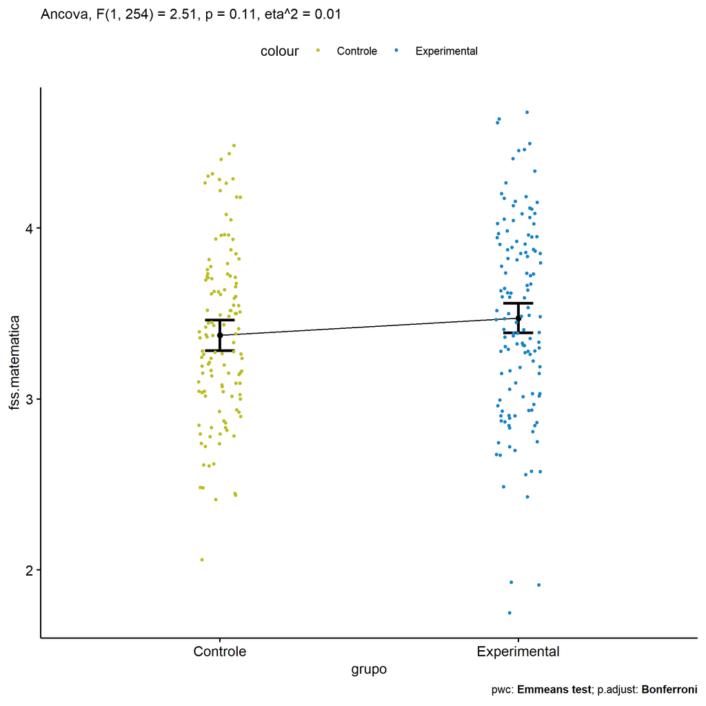

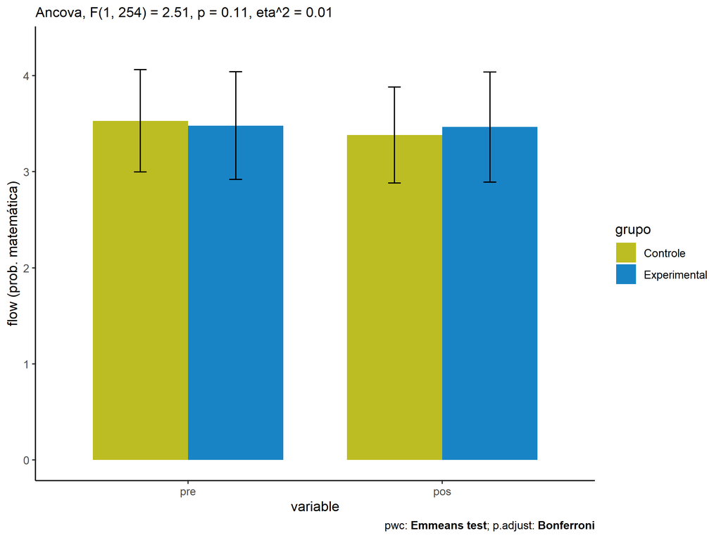

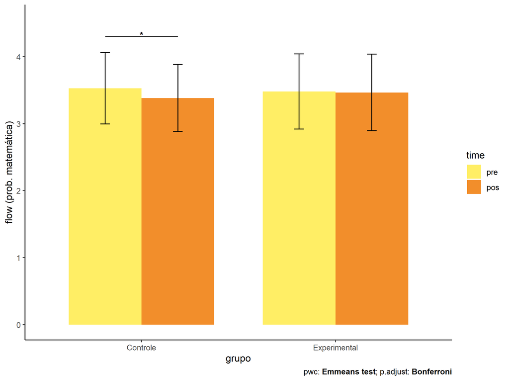

### factor: **genero**

| var | genero | n | M (pre) | SE (pre) | M (unadj) | SE (unadj) | M (adj) | SE (adj) |
| --- | --- | --- | --- | --- | --- | --- | --- | --- |
| fss.matematica | F | 117 | 3.534 | 0.054 | 3.443 | 0.049 | 3.433 | 0.047 |
| fss.matematica | M | 140 | 3.478 | 0.044 | 3.408 | 0.046 | 3.417 | 0.043 |

| .y. | group1 | group2 | estimate | conf.low | conf.high | se | statistic | p | p.adj | p.adj.signif |
| --- | --- | --- | --- | --- | --- | --- | --- | --- | --- | --- |
| fss.matematica | F | M | 0.016 | -0.110 | 0.142 | 0.064 | 0.247 | 0.805 | 0.805 | ns |
| dfs.matematica | F | M | 0.056 | -0.079 | 0.191 | 0.069 | 0.820 | 0.413 | 0.413 | ns |

| .y. | genero | group1 | group2 | estimate | conf.low | conf.high | se | statistic | p | p.adj | p.adj.signif |
| --- | --- | --- | --- | --- | --- | --- | --- | --- | --- | --- | --- |
| flow.matematica | F | pre | pos | 0.091 | -0.048 | 0.231 | 0.071 | 1.286 | 0.199 | 0.199 | ns |
| flow.matematica | M | pre | pos | 0.070 | -0.058 | 0.197 | 0.065 | 1.071 | 0.284 | 0.284 | ns |

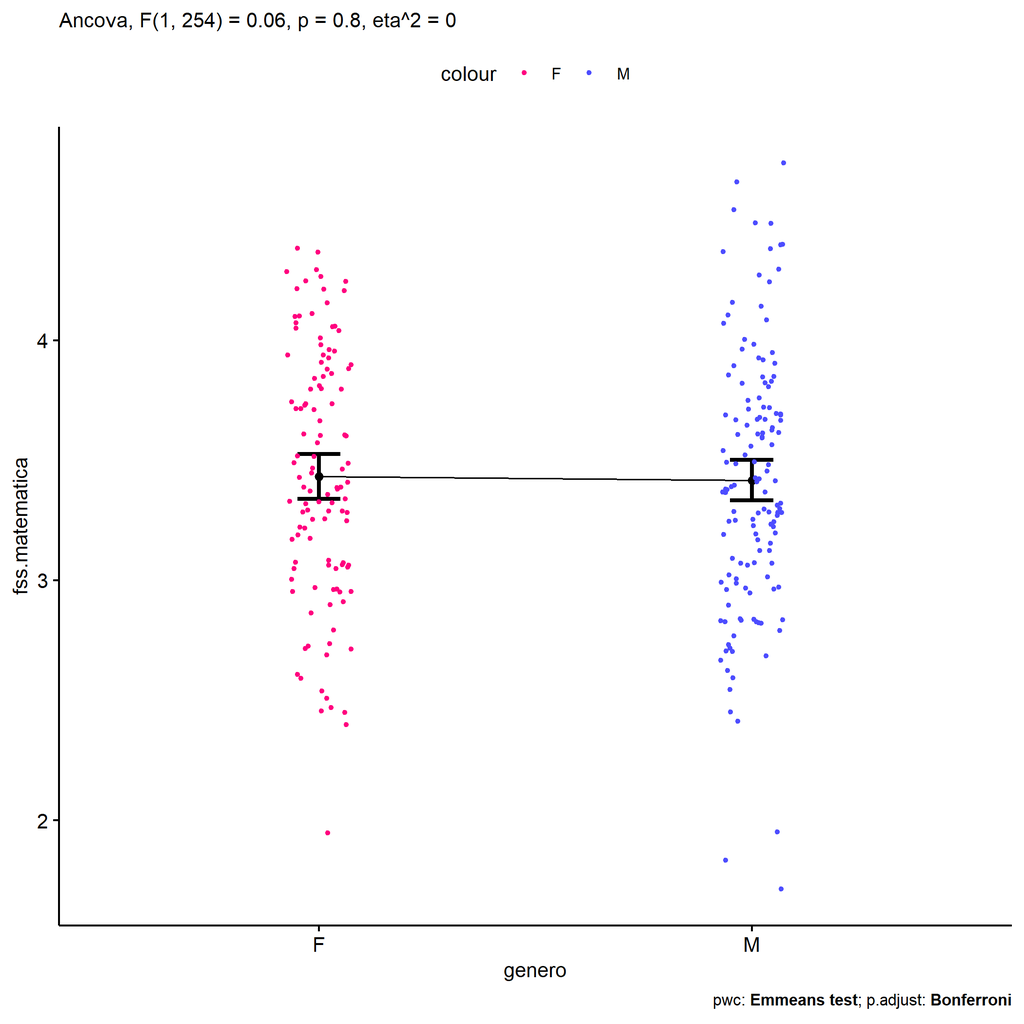

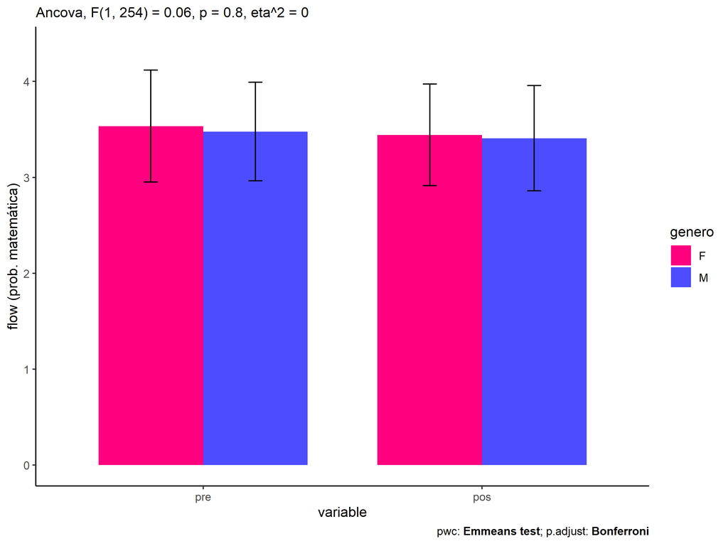

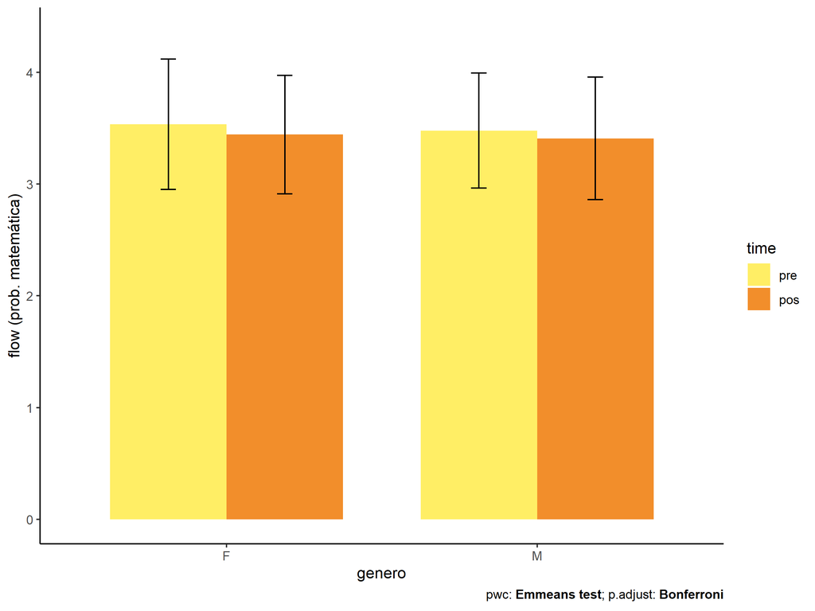

### factor: **idade**

| var | idade | n | M (pre) | SE (pre) | M (unadj) | SE (unadj) | M (adj) | SE (adj) |
| --- | --- | --- | --- | --- | --- | --- | --- | --- |
| fss.matematica | 10y | 48 | 3.445 | 0.076 | 3.361 | 0.084 | 3.384 | 0.073 |
| fss.matematica | 11y | 147 | 3.548 | 0.045 | 3.473 | 0.044 | 3.462 | 0.041 |
| fss.matematica | 12y | 34 | 3.484 | 0.097 | 3.452 | 0.088 | 3.463 | 0.086 |
| fss.matematica | 13y | 16 | 3.479 | 0.140 | 3.078 | 0.111 | 3.090 | 0.126 |

| .y. | group1 | group2 | estimate | conf.low | conf.high | se | statistic | p | p.adj | p.adj.signif |
| --- | --- | --- | --- | --- | --- | --- | --- | --- | --- | --- |
| fss.matematica | 10y | 11y | -0.078 | -0.243 | 0.087 | 0.084 | -0.932 | 0.352 | 1.000 | ns |
| fss.matematica | 10y | 12y | -0.078 | -0.300 | 0.143 | 0.113 | -0.695 | 0.487 | 1.000 | ns |
| fss.matematica | 10y | 13y | 0.294 | 0.009 | 0.580 | 0.145 | 2.031 | 0.043 | 0.260 | ns |
| fss.matematica | 11y | 12y | 0.000 | -0.189 | 0.188 | 0.096 | -0.003 | 0.997 | 1.000 | ns |
| fss.matematica | 11y | 13y | 0.372 | 0.112 | 0.633 | 0.132 | 2.816 | 0.005 | 0.032 | * |
| fss.matematica | 12y | 13y | 0.373 | 0.073 | 0.673 | 0.152 | 2.448 | 0.015 | 0.090 | ns |
| dfs.matematica | 10y | 11y | -0.103 | -0.281 | 0.075 | 0.091 | -1.138 | 0.256 | 1.000 | ns |
| dfs.matematica | 10y | 12y | -0.039 | -0.280 | 0.201 | 0.122 | -0.322 | 0.748 | 1.000 | ns |
| dfs.matematica | 10y | 13y | -0.034 | -0.344 | 0.275 | 0.157 | -0.219 | 0.827 | 1.000 | ns |
| dfs.matematica | 11y | 12y | 0.064 | -0.140 | 0.268 | 0.104 | 0.615 | 0.539 | 1.000 | ns |
| dfs.matematica | 11y | 13y | 0.069 | -0.214 | 0.351 | 0.143 | 0.479 | 0.633 | 1.000 | ns |
| dfs.matematica | 12y | 13y | 0.005 | -0.320 | 0.330 | 0.165 | 0.030 | 0.976 | 1.000 | ns |

| .y. | idade | group1 | group2 | estimate | conf.low | conf.high | se | statistic | p | p.adj | p.adj.signif |
| --- | --- | --- | --- | --- | --- | --- | --- | --- | --- | --- | --- |
| flow.matematica | 10y | pre | pos | 0.084 | -0.132 | 0.300 | 0.110 | 0.760 | 0.447 | 0.447 | ns |
| flow.matematica | 11y | pre | pos | 0.074 | -0.049 | 0.198 | 0.063 | 1.183 | 0.237 | 0.237 | ns |
| flow.matematica | 12y | pre | pos | 0.032 | -0.225 | 0.288 | 0.131 | 0.242 | 0.809 | 0.809 | ns |
| flow.matematica | 13y | pre | pos | 0.401 | 0.027 | 0.775 | 0.190 | 2.105 | 0.036 | 0.036 | * |

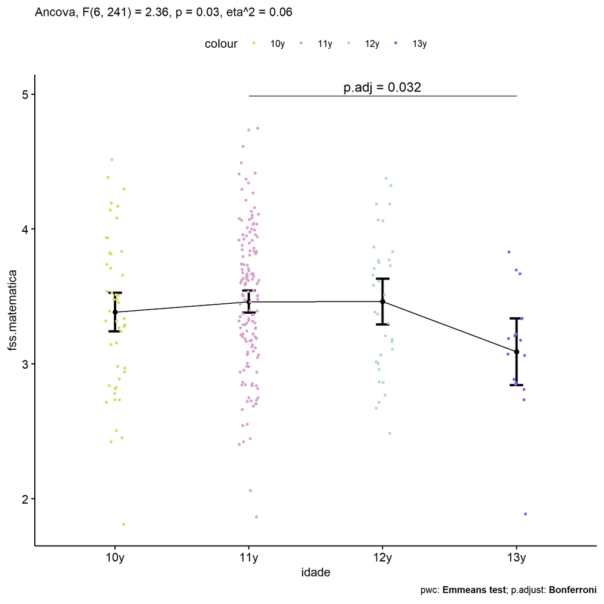

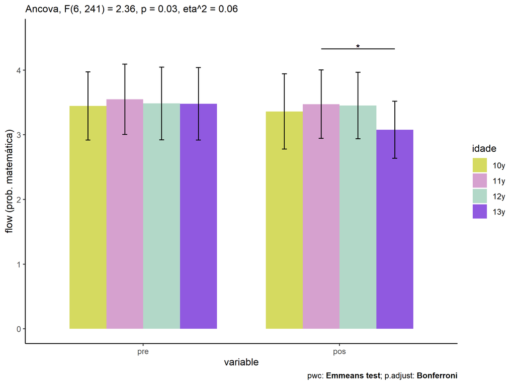

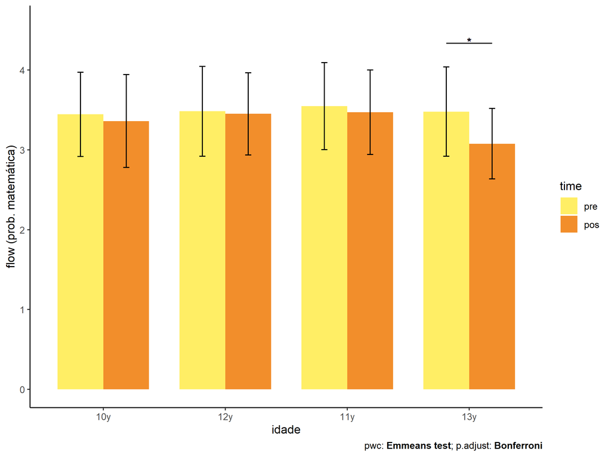

### factor: **zona.participante**

| var | zona.participante | n | M (pre) | SE (pre) | M (unadj) | SE (unadj) | M (adj) | SE (adj) |
| --- | --- | --- | --- | --- | --- | --- | --- | --- |
| fss.matematica | Rural | 96 | 3.534 | 0.058 | 3.437 | 0.053 | 3.418 | 0.053 |
| fss.matematica | Urbana | 103 | 3.411 | 0.054 | 3.378 | 0.056 | 3.396 | 0.051 |

| .y. | group1 | group2 | estimate | conf.low | conf.high | se | statistic | p | p.adj | p.adj.signif |
| --- | --- | --- | --- | --- | --- | --- | --- | --- | --- | --- |
| fss.matematica | Urbana | Rural | -0.022 | -0.168 | 0.124 | 0.074 | -0.299 | 0.765 | 0.765 | ns |
| dfs.matematica | Urbana | Rural | -0.123 | -0.279 | 0.033 | 0.079 | -1.554 | 0.122 | 0.122 | ns |

| .y. | zona.participante | group1 | group2 | estimate | conf.low | conf.high | se | statistic | p | p.adj | p.adj.signif |
| --- | --- | --- | --- | --- | --- | --- | --- | --- | --- | --- | --- |
| flow.matematica | Urbana | pre | pos | 0.033 | -0.118 | 0.183 | 0.077 | 0.430 | 0.667 | 0.667 | ns |
| flow.matematica | Rural | pre | pos | 0.097 | -0.059 | 0.253 | 0.079 | 1.226 | 0.221 | 0.221 | ns |

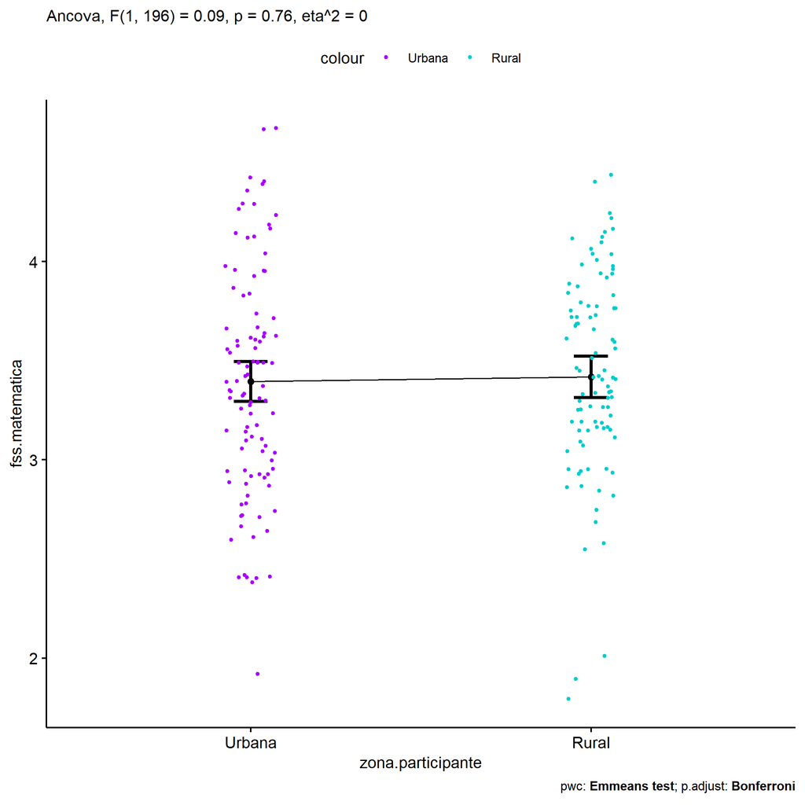

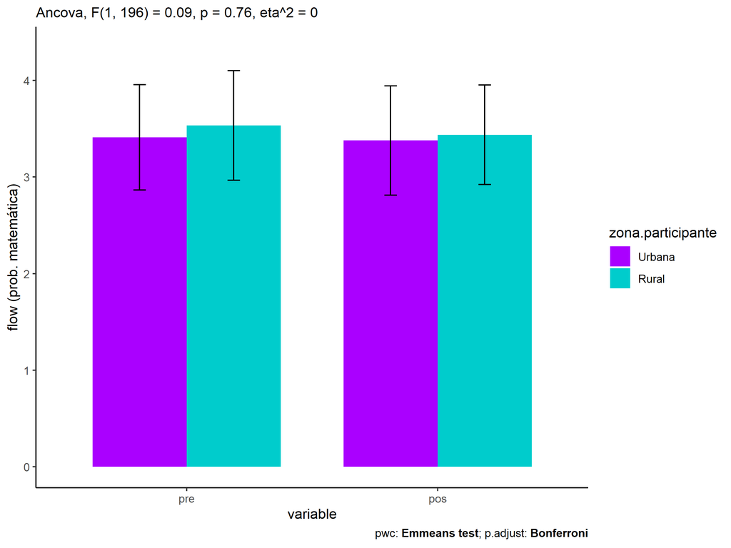

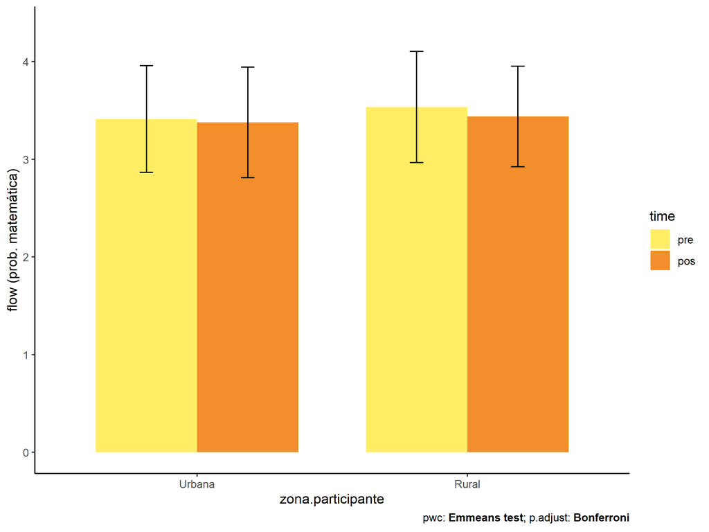

### factor: **escola**

| var | escola | n | M (pre) | SE (pre) | M (unadj) | SE (unadj) | M (adj) | SE (adj) |
| --- | --- | --- | --- | --- | --- | --- | --- | --- |
| fss.matematica | E1 | 22 | 3.203 | 0.109 | 3.431 | 0.140 | 3.534 | 0.109 |
| fss.matematica | E2 | 49 | 3.483 | 0.072 | 3.302 | 0.072 | 3.309 | 0.072 |
| fss.matematica | E3 | 30 | 3.658 | 0.115 | 3.340 | 0.082 | 3.287 | 0.093 |
| fss.matematica | E4 | 30 | 3.606 | 0.079 | 3.503 | 0.075 | 3.468 | 0.093 |
| fss.matematica | E5 | 102 | 3.450 | 0.057 | 3.438 | 0.059 | 3.456 | 0.050 |
| fss.matematica | E6 | 24 | 3.727 | 0.084 | 3.616 | 0.090 | 3.540 | 0.104 |

| .y. | group1 | group2 | estimate | conf.low | conf.high | se | statistic | p | p.adj | p.adj.signif |
| --- | --- | --- | --- | --- | --- | --- | --- | --- | --- | --- |
| fss.matematica | E1 | E2 | 0.224 | -0.034 | 0.482 | 0.131 | 1.711 | 0.088 | 1.000 | ns |
| fss.matematica | E1 | E3 | 0.246 | -0.039 | 0.531 | 0.145 | 1.701 | 0.090 | 1.000 | ns |
| fss.matematica | E1 | E4 | 0.066 | -0.218 | 0.350 | 0.144 | 0.457 | 0.648 | 1.000 | ns |
| fss.matematica | E1 | E5 | 0.078 | -0.158 | 0.314 | 0.120 | 0.649 | 0.517 | 1.000 | ns |
| fss.matematica | E1 | E6 | -0.006 | -0.307 | 0.294 | 0.153 | -0.042 | 0.967 | 1.000 | ns |
| fss.matematica | E2 | E3 | 0.022 | -0.210 | 0.254 | 0.118 | 0.187 | 0.852 | 1.000 | ns |
| fss.matematica | E2 | E4 | -0.158 | -0.390 | 0.073 | 0.118 | -1.346 | 0.180 | 1.000 | ns |
| fss.matematica | E2 | E5 | -0.146 | -0.320 | 0.027 | 0.088 | -1.663 | 0.098 | 1.000 | ns |
| fss.matematica | E2 | E6 | -0.230 | -0.480 | 0.020 | 0.127 | -1.815 | 0.071 | 1.000 | ns |
| fss.matematica | E3 | E4 | -0.180 | -0.438 | 0.077 | 0.131 | -1.379 | 0.169 | 1.000 | ns |
| fss.matematica | E3 | E5 | -0.168 | -0.377 | 0.040 | 0.106 | -1.590 | 0.113 | 1.000 | ns |
| fss.matematica | E3 | E6 | -0.252 | -0.526 | 0.021 | 0.139 | -1.820 | 0.070 | 1.000 | ns |
| fss.matematica | E4 | E5 | 0.012 | -0.196 | 0.220 | 0.106 | 0.113 | 0.910 | 1.000 | ns |
| fss.matematica | E4 | E6 | -0.072 | -0.346 | 0.201 | 0.139 | -0.520 | 0.603 | 1.000 | ns |
| fss.matematica | E5 | E6 | -0.084 | -0.313 | 0.144 | 0.116 | -0.725 | 0.469 | 1.000 | ns |
| dfs.matematica | E1 | E2 | -0.280 | -0.550 | -0.009 | 0.137 | -2.035 | 0.043 | 0.643 | ns |
| dfs.matematica | E1 | E3 | -0.454 | -0.750 | -0.158 | 0.150 | -3.023 | 0.003 | 0.041 | * |
| dfs.matematica | E1 | E4 | -0.403 | -0.699 | -0.107 | 0.150 | -2.682 | 0.008 | 0.117 | ns |
| dfs.matematica | E1 | E5 | -0.247 | -0.495 | 0.001 | 0.126 | -1.962 | 0.051 | 0.763 | ns |
| dfs.matematica | E1 | E6 | -0.524 | -0.835 | -0.212 | 0.158 | -3.312 | 0.001 | 0.016 | * |
| dfs.matematica | E2 | E3 | -0.175 | -0.419 | 0.070 | 0.124 | -1.408 | 0.160 | 1.000 | ns |
| dfs.matematica | E2 | E4 | -0.123 | -0.368 | 0.121 | 0.124 | -0.995 | 0.321 | 1.000 | ns |
| dfs.matematica | E2 | E5 | 0.033 | -0.151 | 0.216 | 0.093 | 0.351 | 0.726 | 1.000 | ns |
| dfs.matematica | E2 | E6 | -0.244 | -0.507 | 0.019 | 0.133 | -1.828 | 0.069 | 1.000 | ns |
| dfs.matematica | E3 | E4 | 0.051 | -0.221 | 0.324 | 0.138 | 0.371 | 0.711 | 1.000 | ns |
| dfs.matematica | E3 | E5 | 0.207 | -0.012 | 0.426 | 0.111 | 1.865 | 0.063 | 0.950 | ns |
| dfs.matematica | E3 | E6 | -0.069 | -0.358 | 0.220 | 0.147 | -0.471 | 0.638 | 1.000 | ns |
| dfs.matematica | E4 | E5 | 0.156 | -0.063 | 0.375 | 0.111 | 1.404 | 0.161 | 1.000 | ns |
| dfs.matematica | E4 | E6 | -0.120 | -0.409 | 0.168 | 0.147 | -0.821 | 0.413 | 1.000 | ns |
| dfs.matematica | E5 | E6 | -0.277 | -0.516 | -0.037 | 0.121 | -2.276 | 0.024 | 0.355 | ns |

| .y. | escola | group1 | group2 | estimate | conf.low | conf.high | se | statistic | p | p.adj | p.adj.signif |
| --- | --- | --- | --- | --- | --- | --- | --- | --- | --- | --- | --- |
| flow.matematica | E1 | pre | pos | -0.228 | -0.546 | 0.089 | 0.162 | -1.411 | 0.159 | 0.159 | ns |
| flow.matematica | E2 | pre | pos | 0.181 | -0.032 | 0.393 | 0.108 | 1.667 | 0.096 | 0.096 | ns |
| flow.matematica | E3 | pre | pos | 0.318 | 0.046 | 0.590 | 0.138 | 2.296 | 0.022 | 0.022 | * |
| flow.matematica | E4 | pre | pos | 0.104 | -0.168 | 0.376 | 0.138 | 0.750 | 0.454 | 0.454 | ns |
| flow.matematica | E5 | pre | pos | 0.013 | -0.135 | 0.160 | 0.075 | 0.168 | 0.866 | 0.866 | ns |
| flow.matematica | E6 | pre | pos | 0.111 | -0.193 | 0.415 | 0.155 | 0.718 | 0.473 | 0.473 | ns |

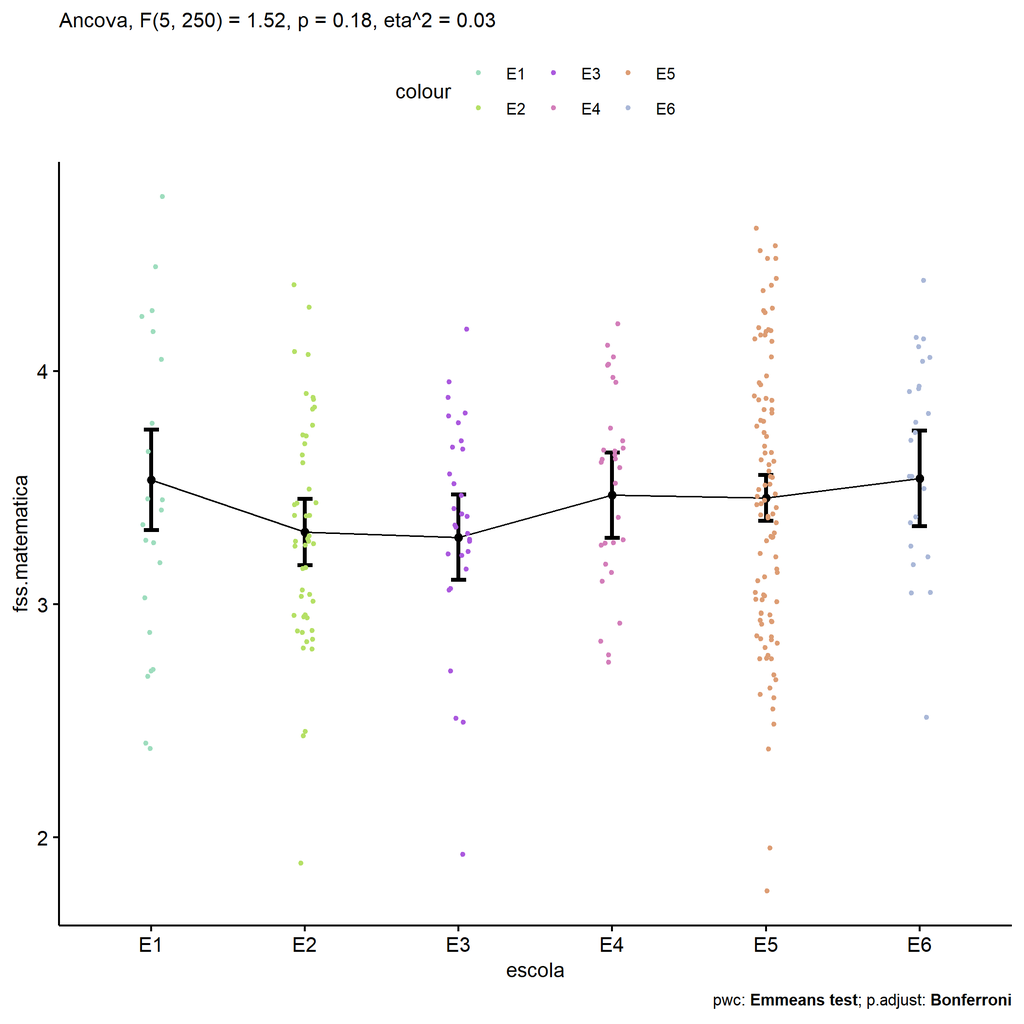

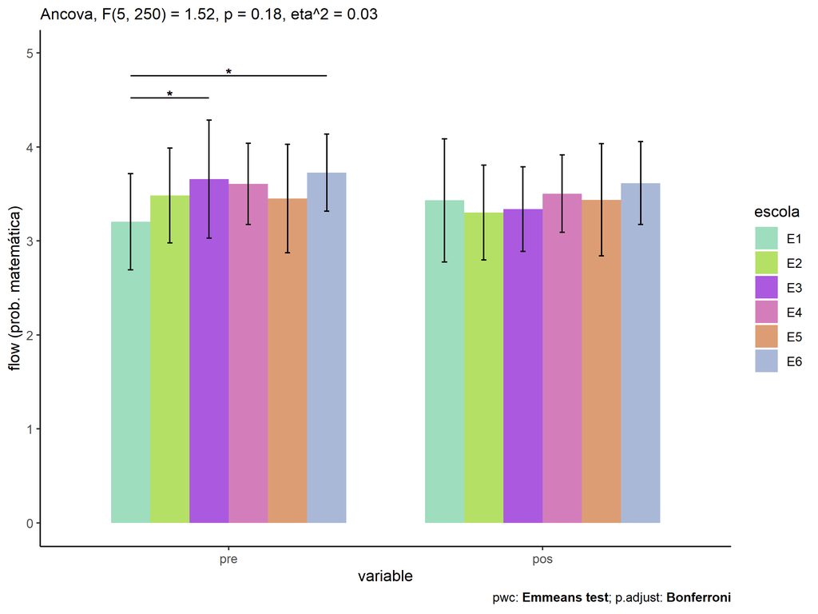

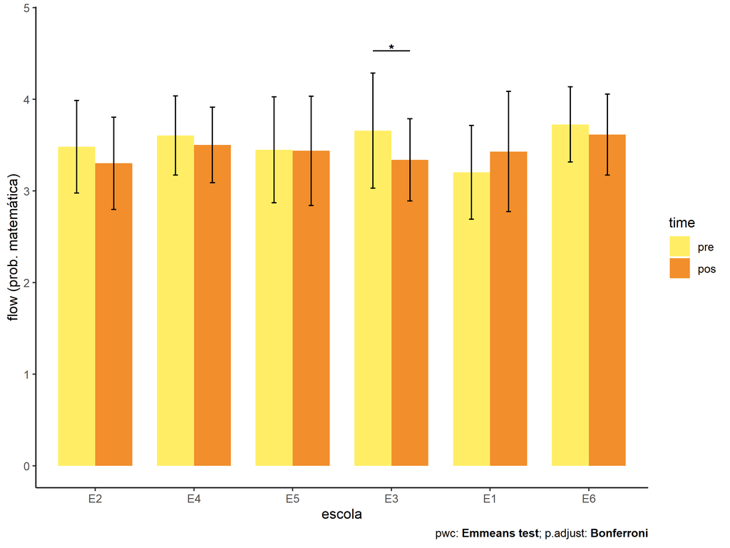

### factor: **zona.escola**

| var | zona.escola | n | M (pre) | SE (pre) | M (unadj) | SE (unadj) | M (adj) | SE (adj) |
| --- | --- | --- | --- | --- | --- | --- | --- | --- |
| fss.matematica | Rural | 84 | 3.659 | 0.055 | 3.477 | 0.048 | 3.425 | 0.056 |
| fss.matematica | Urbana | 173 | 3.428 | 0.042 | 3.399 | 0.044 | 3.424 | 0.039 |

| .y. | group1 | group2 | estimate | conf.low | conf.high | se | statistic | p | p.adj | p.adj.signif |
| --- | --- | --- | --- | --- | --- | --- | --- | --- | --- | --- |
| fss.matematica | Urbana | Rural | -0.002 | -0.138 | 0.134 | 0.069 | -0.026 | 0.979 | 0.979 | ns |
| dfs.matematica | Urbana | Rural | -0.231 | -0.372 | -0.090 | 0.071 | -3.236 | 0.001 | 0.001 | ** |

| .y. | zona.escola | group1 | group2 | estimate | conf.low | conf.high | se | statistic | p | p.adj | p.adj.signif |
| --- | --- | --- | --- | --- | --- | --- | --- | --- | --- | --- | --- |
| flow.matematica | Urbana | pre | pos | 0.030 | -0.084 | 0.143 | 0.058 | 0.512 | 0.609 | 0.609 | ns |
| flow.matematica | Rural | pre | pos | 0.182 | 0.019 | 0.345 | 0.083 | 2.198 | 0.028 | 0.028 | * |

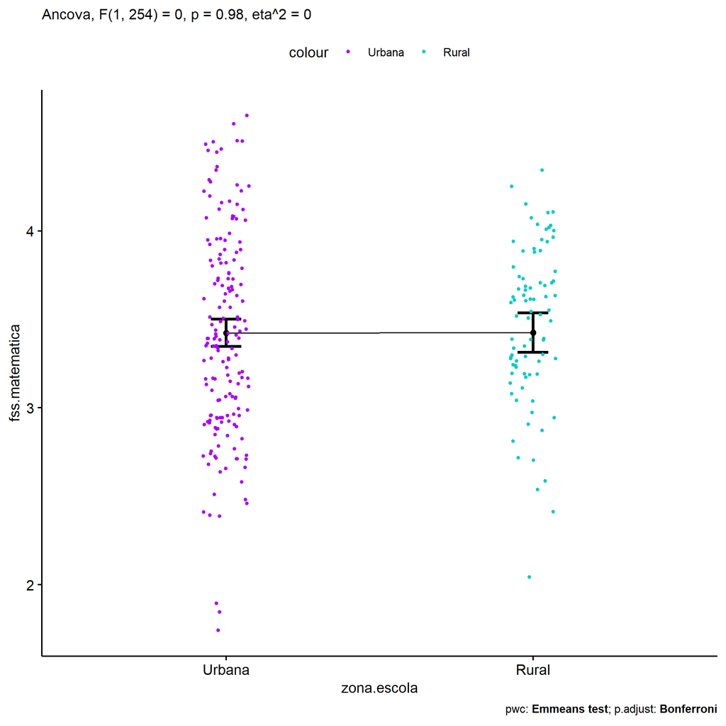

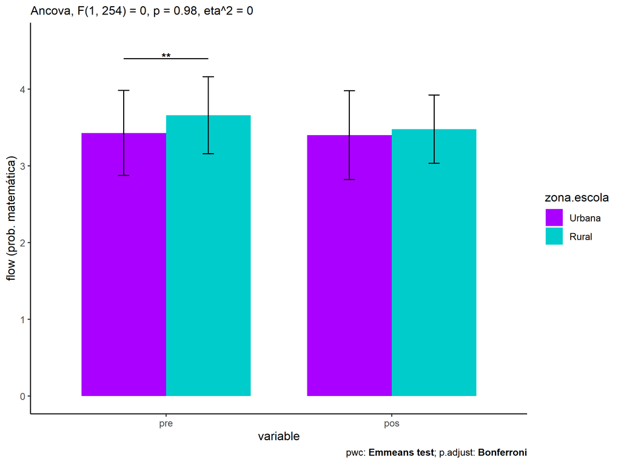

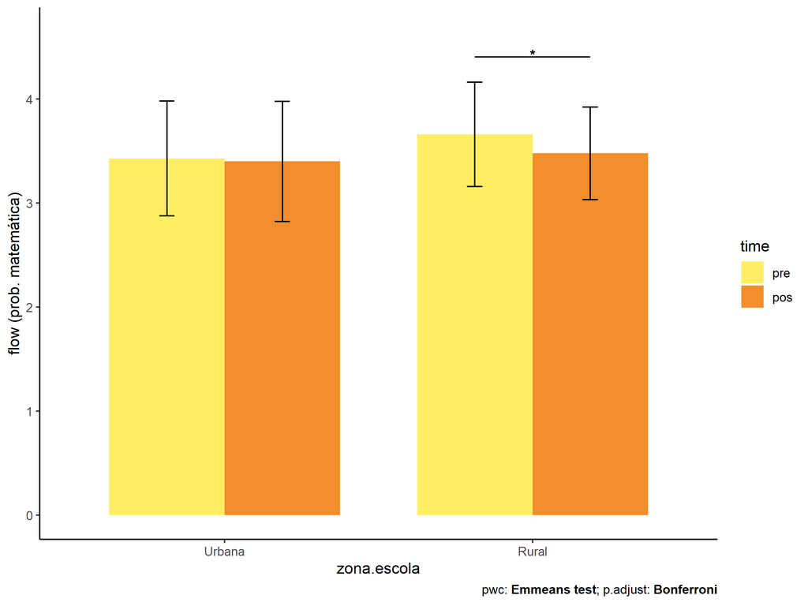